# Preliminary-result

Authors

Jorge Alberto Espejel Padilla

Md Mehedi Hassan Sharif

Amala Thomas

Ei Mon Thant

Published

January 8, 2025

# 1. Title

Analysis of the data set from the project “The nectar report: quantitative review of nectar sugar concentrations offered by bee visited flowers in agricultural and non-agricultural landscapes”

# 2. Introduction

**Introduction**

Nectar is a critical resource in plant-pollinator interactions, influencing pollinator behavior, visitation rates, and plant reproductive success.

Its sugar composition—primarily sucrose, glucose, and fructose—serves as a key determinant of nectar quality and pollinator preference (Nicolson & Thornburg, 2007). Variations in nectar sugar concentration have been linked to ecological, evolutionary, and environmental factors, including plant taxonomy, geographical region, and climate conditions (Pacini & Nepi, 2007; Ornelas et al., 2019). Understanding these variations is crucial for elucidating the role of nectar traits in shaping plant-pollinator dynamics. Taxonomy plays a significant role in determining nectar composition.

Differences in sugar ratios have been observed at both the family and genus levels, with phylogenetic constraints often influencing nectar traits (Perret et al., 2001; Chalcoff et al., 2006). For example, hummingbird-pollinated flowers tend to produce sucrose-dominant nectars, while bee-pollinated flowers show balanced sugar proportions (Rodríguez-Gironés & Santamaría, 2004; Nicolson & Thornburg, 2007). These variations highlight evolutionary adaptations to pollinator syndromes. In addition to taxonomy, geographic factors contribute to variability in nectar traits.

Nectar sugar concentration has been shown to vary across regions, likely as a response to climatic factors such as temperature, rainfall, and latitude (Pacini & Nepi, 2007; Stiles & Freeman, 1993). For instance, studies in temperate and tropical regions have reported regional differences in nectar sugar concentration, influenced by both plant phylogeny and environmental conditions (Petanidou, 2005; Chalcoff et al., 2006). These findings underscore the interplay between evolutionary processes and environmental pressures in shaping nectar characteristics globally. Recent work, such as Ornelas et al. (2019), has revealed significant variation in nectar sugar concentration across families, genera, and continents, reflecting both fixed effects (taxonomic constraints) and random effects (environmental variability). Identifying these patterns is essential for understanding how nectar traits evolve and adapt in different ecological and climatic contexts. This study aims to analyze the variability in nectar sugar concentration across taxonomic levels and geographical regions.

# 3. Objectives and Hypotheses

## Objectives

**Primary Objective**:

To investigate the relationships between plant taxonomy (e.g., family, genus), geography and nectar sugar concentration.

**Secondary Objective**

To investigate sugar concentration variability between crops and weeds, identifying ecological factors driving the observed differences.

## Hypotheses

**Primary Hypothesis**:

**H₀ (Null Hypothesis)**: There is no significant relationship between plant taxonomy (family, genus) and nectar sugar concentration.

**H₁ (Alternative Hypothesis)**: Plant taxonomy significantly affects nectar sugar concentration.

**Secondary Hypotheses**:

**Geographical Variation**:

**H₀**: Nectar sugar concentration does not vary significantly across geographical regions (continents or hemispheres).

**H₁**: Nectar sugar concentration varies significantly across geographical regions.

**Ecological Effects:**

**H₀:** Nectar sugar concentrations do not significantly differ among crops, weeds, and wild plants.

**H₁:** Nectar sugar concentrations significantly differ among crops, weeds, and wild plants.

# 4. Methods

### 2. Boxplot Analysis: Nectar Sugar Concentration by Family

**Objective**: Visualize the distribution of nectar sugar concentration across different plant families.

**Analyses**:

- Ensured nectar sugar concentration values were properly formatted as numeric for analysis.
- Created boxplots to visualize nectar sugar concentration distribution across families.
- Ordered families by their median sugar concentration to enhance interpretability.
- Highlighted outliers in the data for better identification of deviations from typical value

### 3. **Pairwise Comparisons with Dunn’s Test**:

- **Objective**: Identify pairwise differences in nectar sugar concentration.
- **Analyses**:
  - Performed **Dunn’s test** for pairwise comparisons at both:
    - **Family** and **Genus** levels.
  - Adjusted p-values using the **Bonferroni correction**.
  - Highlighted significant pairwise comparisons in barplots.

### 4. **Linear Mixed-Effects Model**:

- **Objective**: Assess variability in nectar sugar concentration within and across Families and Genera.
- **Analyses**:
  - Fitted a **linear mixed-effects model**:
    - Included **Genus nested within Family** as random effects.
  - Examined fixed and random effects.
  - Visualized random effects using barplots for top/bottom genera.

### 5. **Geographical Effects on Sugar Concentration**:

- **Objective**: Explore geographical variability in nectar sugar concentration.
- **Analyses**:
  - Tested sugar concentration across continents using:
    - **ANOVA** (if data were normal) or **Kruskal-Wallis** (if non-normal).
  - Visualized results with boxplots and geospatial maps highlighting mean sugar concentration per region.

### 6. **Ecological Effects (Crops vs. Weeds)**:

- **Objective**: Compare sugar concentration between crops and weeds.
- **Analyses**:
  - Created **boxplots** to visualize differences between plant types.
  - Used **Kruskal-Wallis tests** to test for significant differences.
  - Performed **Dunn’s test** for pairwise comparisons between plant types.

### 8. **Phylogenetic Analysis**:

- **Objective**: Assess evolutionary patterns in nectar sugar concentration.
- **Analyses**:
  - Matched Family names with Open Tree of Life identifiers.
  - Constructed a **phylogenetic tree** and tested for **phylogenetic signal**.
  - Mapped sugar concentration as a heatmap on the tree.

### 9. **Heatmap of Sugar Concentration by Family**:

- **Objective**: Visualize sugar concentration aligned with phylogenetic tree order.
- **Analyses**:
  - Aligned Family order from the phylogenetic tree.
  - Mapped mean sugar concentration using a heatmap.
  - Adjusted visualization for improved readability.

# 5. Results

#### 1. **Summary Statistics**

The descriptive analysis summarized nectar sugar concentration across families, genera, and geographical regions. Results indicate significant variability in sugar concentrations:

**Figure 1**: Mean nectar sugar concentration (%) by Family and Region.

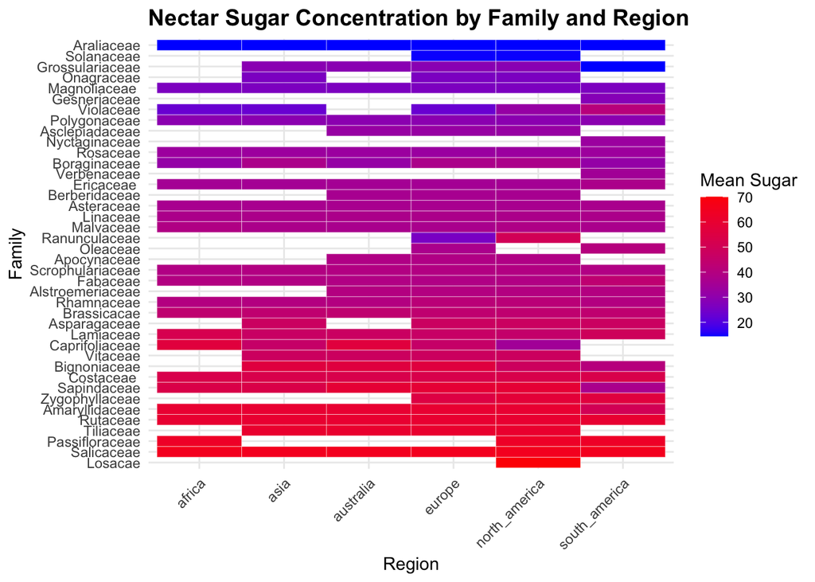

```r
# Load the dataset
bee_data <- read.csv("cleaned_bee_nectar_data.csv", stringsAsFactors = FALSE)

# Convert sugar_concentration to numeric (in case of issues)
bee_data$sugar_concentration <- as.numeric(bee_data$sugar_concentration)

# Transform data for heatmap
heatmap_data <- bee_data %>%
  gather(key = "Region", value = "Presence", europe:australia) %>%
  filter(Presence == "yes") %>%
  group_by(Family, Region) %>%
  summarise(mean_sugar = mean(sugar_concentration, na.rm = TRUE)) %>%
  ungroup()

# Create heatmap visualization
ggplot(heatmap_data, aes(x = Region, y = reorder(Family, -mean_sugar), fill = mean_sugar)) +
  geom_tile(color = "white") +
  scale_fill_gradient(low = "blue", high = "red", na.value = "grey", name = "Mean Sugar") +
  labs(
    title = "Nectar Sugar Concentration by Family and Region",
    x = "Region",
    y = "Family"
  ) +
  theme_minimal() +
  theme(
    axis.text.x = element_text(angle = 45, hjust = 1),
    plot.title = element_text(size = 14, face = "bold")
  )
```

#### **2. Taxonomic Effects on Nectar Sugar Concentration**

The analysis of nectar sugar concentration revealed significant variability across taxonomic levels. Two approaches were used to assess this: boxplots and random effects modeling.

#### **Boxplot Analysis**

A boxplot of nectar sugar concentration grouped by family (Figure 2) revealed distinct patterns of variability across families. While some families exhibited a wide range of sugar concentrations, others showed narrower distributions. Outliers in some families suggest genera with sugar concentrations that deviate significantly from the family median.

#### 3. Pairwise Comparisons Analysis:

**Figure 2**: Nectar sugar concentration by family.  
**Figure 3 and 4**: Significant pairwise comparisons at the Family and Genus level.

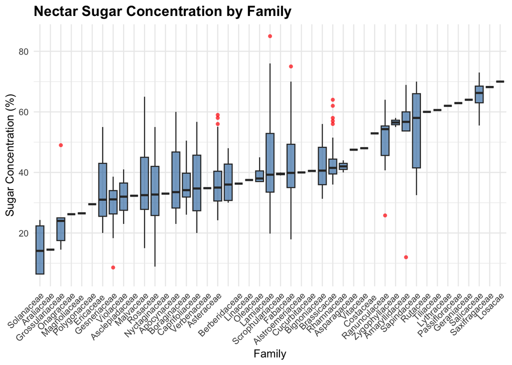

```r
# Ensure sugar_concentration is numeric
bee_data$sugar_concentration <- as.numeric(bee_data$sugar_concentration)

# Boxplot for Taxonomic Effects by Family
ggplot(bee_data, aes(x = reorder(Family, sugar_concentration, FUN = median), y = sugar_concentration)) +
  geom_boxplot(fill = "steelblue", alpha = 0.7, outlier.color = "red", outlier.shape = 16) +
  labs(
    title = "Nectar Sugar Concentration by Family",
    x = "Family",
    y = "Sugar Concentration (%)"
  ) +
  theme_minimal() +
  theme(
    axis.text.x = element_text(angle = 45, hjust = 1),
    plot.title = element_text(size = 14, face = "bold")
  )
```

```r
# Perform Dunn's Test for Pairwise Comparisons at the Family Level
dunn_family <- dunnTest(sugar_concentration ~ Family, data = bee_data, method = "bonferroni")
dunn_family_results <- dunn_family$res

# Check column names of the Dunn test results
print(names(dunn_family_results))  # Debugging step to confirm column names
```

```
[1] "Comparison" "Z"          "P.unadj"    "P.adj"
```

```r
# Extract significant comparisons for Family level
significant_family <- dunn_family_results %>%
  mutate(
    comparison = Comparison  # Use 'Comparison' column directly
  ) %>%
  filter(P.adj < 0.05) %>%
  arrange(P.adj)

print("Significant Pairwise Comparisons Between Families:")
```

```
[1] "Significant Pairwise Comparisons Between Families:"
```

```r
print(significant_family)
```

```
                  Comparison         Z      P.unadj        P.adj
1     Brassicacae - Rosaceae  5.045638 4.520100e-07 0.0004474899
2    Salicaceae - Solanaceae  4.516266 6.293950e-06 0.0062310101
3        Fabaceae - Rosaceae  4.408675 1.040048e-05 0.0102964798
4 Ranunculaceae - Solanaceae  4.332437 1.474680e-05 0.0145993318
5   Ranunculaceae - Rosaceae  4.270960 1.946337e-05 0.0192687379
6   Asteraceae - Brassicacae -4.165322 3.109136e-05 0.0307804420
7   Brassicacae - Solanaceae  4.154158 3.264870e-05 0.0323222108
                  comparison
1     Brassicacae - Rosaceae
2    Salicaceae - Solanaceae
3        Fabaceae - Rosaceae
4 Ranunculaceae - Solanaceae
5   Ranunculaceae - Rosaceae
6   Asteraceae - Brassicacae
7   Brassicacae - Solanaceae
```

```r
# Perform Dunn's Test for Pairwise Comparisons at the Genus Level
dunn_genus <- dunnTest(sugar_concentration ~ Genus, data = bee_data, method = "bonferroni")
dunn_genus_results <- dunn_genus$res

# Extract significant comparisons for Genus level
significant_genus <- dunn_genus_results %>%
  mutate(
    comparison = Comparison  # Use 'Comparison' column directly
  ) %>%
  filter(P.adj < 0.05) %>%
  arrange(P.adj)

print("Significant Pairwise Comparisons Between Genera:")
```

```
[1] "Significant Pairwise Comparisons Between Genera:"
```

```r
print(significant_genus)
```

```
             Comparison         Z      P.unadj        P.adj
1  Adesmia - Helianthus  5.909836 3.424480e-09 2.128657e-05
2      Adesmia - Prunus  5.552575 2.814921e-08 1.749755e-04
3    Adesmia - Capsicum  5.120430 3.048390e-07 1.894879e-03
4       Adesmia - Pyrus  5.074027 3.894832e-07 2.421027e-03
5   Adesmia - Sinningia  5.063801 4.109793e-07 2.554648e-03
6       Adesmia - Rubus  5.040302 4.647986e-07 2.889188e-03
7     Aconitum - Prunus  4.726900 2.279738e-06 1.417085e-02
8   Aconitum - Capsicum  4.628692 3.679818e-06 2.287375e-02
9    Adesmia - Fragaria  4.613489 3.959650e-06 2.461318e-02
10     Capsicum - Salix -4.516266 6.293950e-06 3.912319e-02
11     Aconitum - Pyrus  4.506512 6.590201e-06 4.096469e-02
12      Adesmia - Ribes  4.471218 7.777524e-06 4.834509e-02
             comparison
1  Adesmia - Helianthus
2      Adesmia - Prunus
3    Adesmia - Capsicum
4       Adesmia - Pyrus
5   Adesmia - Sinningia
6       Adesmia - Rubus
7     Aconitum - Prunus
8   Aconitum - Capsicum
9    Adesmia - Fragaria
10     Capsicum - Salix
11     Aconitum - Pyrus
12      Adesmia - Ribes
```

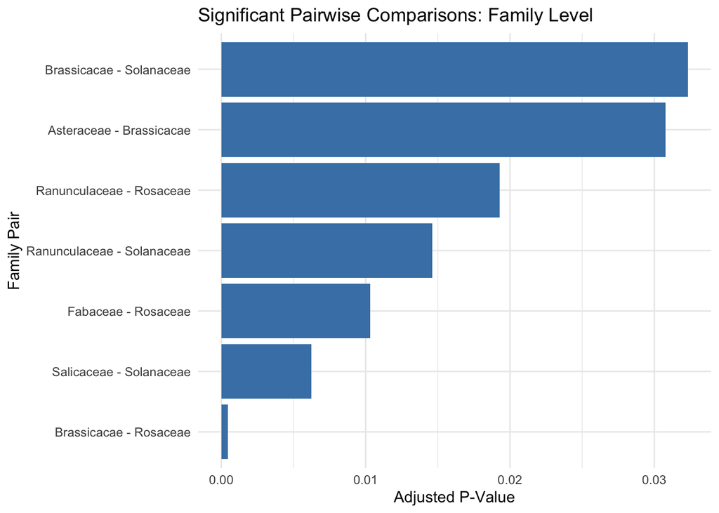

```r
# Visualize Results: Top Significant Comparisons at Family Level
ggplot(significant_family, aes(x = reorder(comparison, P.adj), y = P.adj)) +
  geom_bar(stat = "identity", fill = "steelblue") +
  coord_flip() +
  labs(
    title = "Significant Pairwise Comparisons: Family Level",
    x = "Family Pair",
    y = "Adjusted P-Value"
  ) +
  theme_minimal()
```

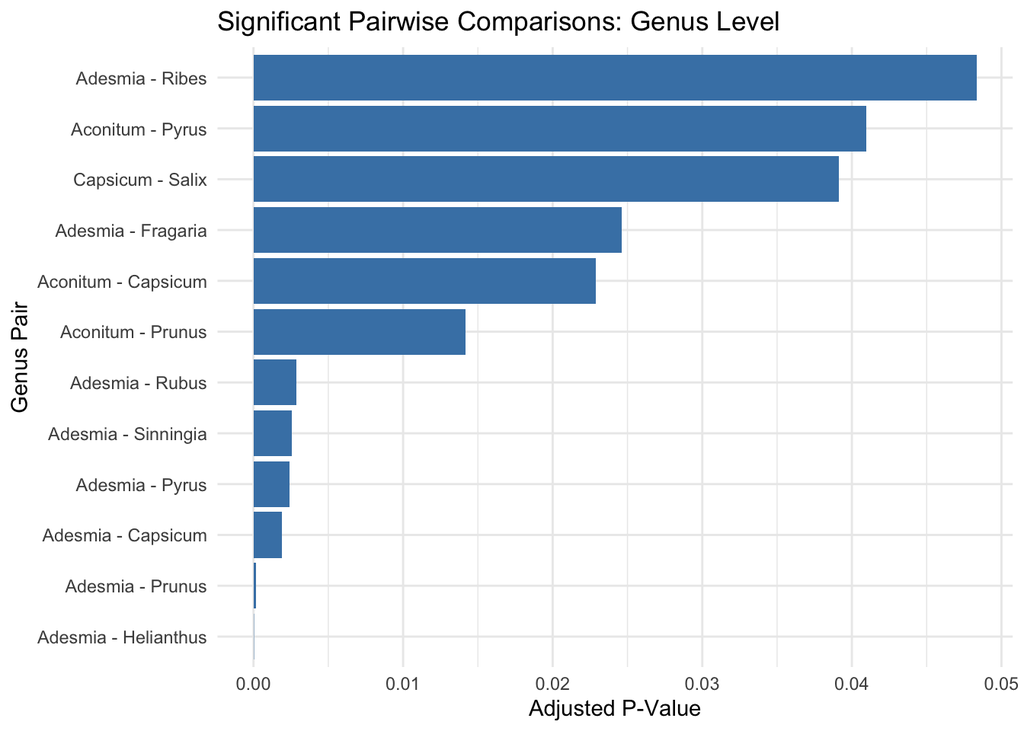

```r
# Visualize Results: Top Significant Comparisons at Genus Level
ggplot(significant_genus, aes(x = reorder(comparison, P.adj), y = P.adj)) +
  geom_bar(stat = "identity", fill = "steelblue") +
  coord_flip() +
  labs(
    title = "Significant Pairwise Comparisons: Genus Level",
    x = "Genus Pair",
    y = "Adjusted P-Value"
  ) +
  theme_minimal()
```

#### **4. Random Effects**

The random effects analysis using a **linear mixed-effects model** assessed the variability in nectar sugar concentration among **genera nested within families**.

**Figure 5**: Distribution of Random Effects: genera Within families  
**Figure 6**: Top and Bottom 10 random effects estimates

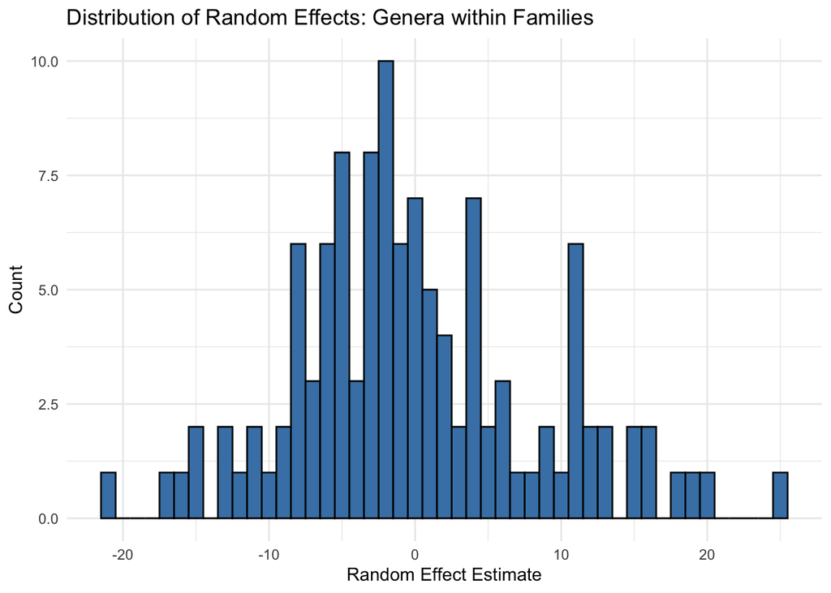

```r
# -------------------------------
# Fit the Linear Mixed-Effects Model
# -------------------------------
# Model: Sugar concentration ~ (1 | Family/Genus) for random effects
lmm_model <- lmer(sugar_concentration ~ 1 + (1 | Family/Genus), data = bee_data)

# -------------------------------
# Extract Random Effects
# -------------------------------
# Extract random effects (Genus within Family)
random_effects <- ranef(lmm_model)$`Genus:Family`

# Convert to data frame
random_effects_df <- as.data.frame(random_effects)
colnames(random_effects_df) <- c("Random_Effect")  # Rename the random effects column

# Add Genus:Family identifiers for clarity
random_effects_df$Genus_Family <- rownames(random_effects)

# Split Family and Genus into separate columns
random_effects_df <- random_effects_df %>%
  separate(Genus_Family, into = c("Family", "Genus"), sep = ":")

# -------------------------------
# Compute Mean Random Effect by Family
# -------------------------------
# Add mean random effect for each family
random_effects_df <- random_effects_df %>%
  group_by(Family) %>%
  mutate(Mean_Family_Effect = mean(Random_Effect)) %>%
  ungroup()

# Arrange by mean family effect
random_effects_df <- random_effects_df %>%
  arrange(desc(Mean_Family_Effect))

# -------------------------------
# Select Top/Bottom 10 Random Effects
# -------------------------------
# Filter top and bottom 10 random effects by absolute value
random_effects_filtered <- random_effects_df %>%
  arrange(desc(abs(Random_Effect))) %>%
  slice(c(1:10, (n() - 9):n()))  # Select top 10 and bottom 10

# -------------------------------
# Visualize Improved Plots
# -------------------------------

# 1. Histogram of Random Effects
ggplot(random_effects_df, aes(x = Random_Effect)) +
  geom_histogram(binwidth = 1, fill = "steelblue", color = "black") +
  labs(
    title = "Distribution of Random Effects: Genera within Families",
    x = "Random Effect Estimate",
    y = "Count"
  ) +
  theme_minimal()
```

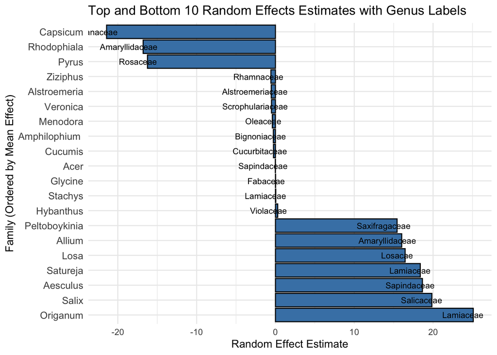

```r
# 2. Improved Barplot for Top/Bottom 10 Random Effects
# Include genus names as labels and order families by mean effect
ggplot(random_effects_filtered, aes(x = reorder(Family, -Mean_Family_Effect), y = Random_Effect)) +
  geom_bar(stat = "identity", fill = "steelblue", color = "black") +
  geom_text(
    aes(label = Genus),
    hjust = 0.75,  # Center the labels horizontally
    vjust = 0.5,  # Center the labels vertically
    color = "black",  # Ensure labels are visible
    size = 3
  ) +
  coord_flip() +
  labs(
    title = "Top and Bottom 10 Random Effects Estimates with Genus Labels",
    x = "Family (Ordered by Mean Effect)",
    y = "Random Effect Estimate"
  ) +
  theme_minimal() +
  theme(axis.text.y = element_text(size = 10))
```

#### 5. **Geographical Effects on Nectar Sugar Concentration and Geospatial Mappnig**

Overall, these findings suggest that geographical location does not play a substantial role in driving differences in nectar sugar concentration.

**Figure 7**: Boxplots of nectar sugar concentration across geographical regions

**Figure 8**: Geospatial mappnig

```r
# -------------------------------
# Data Preparation
# -------------------------------

# Convert geographical regions into factors
bee_data_long <- bee_data %>%
  gather(key = "Region", value = "Presence", europe:australia) %>%
  filter(Presence == "yes") %>%  # Keep only relevant rows
  mutate(Region = factor(Region))  # Convert Region to factor

# Check the structure of the data
str(bee_data_long)
```

```
'data.frame':   1977 obs. of  12 variables:
 $ number             : int  1 2 3 4 5 6 7 8 9 10 ...
 $ Family             : chr  "Rosaceae" "Brassicacae" "Brassicacae" "Rosaceae" ...
 $ Genus              : chr  "Malus" "Raphanus" "Brassica" "Rubus" ...
 $ species            : chr  "domestica" "raphanistrum" "sp" "idaeus" ...
 $ sci_name           : chr  "Malus sp." "Raphanus raphanistrum" "Brassica sp" "Rubus idaeus" ...
 $ variant            : chr  "" "" "" "" ...
 $ sugar_concentration: num  42 40 39 37 34 34 33 31 30 28 ...
 $ type               : chr  "crop" "weed" "crop" "crop" ...
 $ reference          : chr  "Butler, C. G. (1945). The influence of various physical and biological factors of the environment on honeybee a"| __truncated__ "Butler, C. G. (1945). The influence of various physical and biological factors of the environment on honeybee a"| __truncated__ "Butler, C. G…
 $ notes              : chr  "" "" "" "" ...
 $ Region             : Factor w/ 6 levels "africa","asia",..: 4 4 4 4 4 4 4 4 4 4 ...
 $ Presence           : chr  "yes" "yes" "yes" "yes" ...
```

```r
# -------------------------------
# Normality Check (Shapiro-Wilk)
# -------------------------------
# Test for normality of sugar concentration
shapiro_test <- shapiro.test(bee_data_long$sugar_concentration)
print(shapiro_test)
```

```
    Shapiro-Wilk normality test

data:  bee_data_long$sugar_concentration
W = 0.96827, p-value < 2.2e-16
```

```
Data is not normal. Proceeding with Kruskal-Wallis test...

    Kruskal-Wallis rank sum test

data:  sugar_concentration by Region
Kruskal-Wallis chi-squared = 1.0451, df = 5, p-value = 0.9588
```

```
                      Comparison           Z   P.unadj P.adj
1                  africa - asia  0.20717119 0.8358762     1
2             africa - australia  0.28897620 0.7725996     1
3               asia - australia  0.08607713 0.9314051     1
4                africa - europe  0.61516139 0.5384481     1
5                  asia - europe  0.42003203 0.6744621     1
6             australia - europe  0.32961098 0.7416939     1
7         africa - north_america -0.02853842 0.9772327     1
8           asia - north_america -0.24911640 0.8032707     1
9      australia - north_america -0.33536627 0.7373488     1
10        europe - north_america -0.68333139 0.4943975     1
11        africa - south_america -0.27219087 0.7854753     1
12          asia - south_america -0.50128328 0.6161718     1
13     australia - south_america -0.58556120 0.5581704     1
14        europe - south_america -0.93859856 0.3479369     1
15 north_america - south_america -0.25872766 0.7958454     1
```

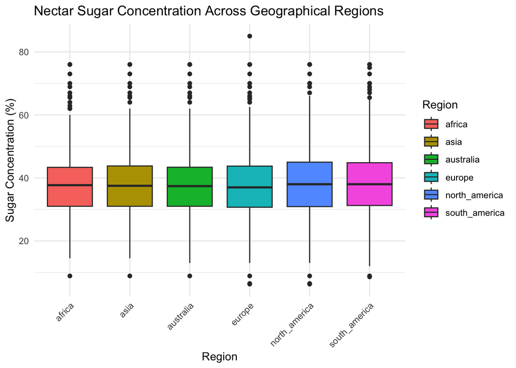

```r
# -------------------------------
# Select Appropriate Test: ANOVA or Kruskal-Wallis
# -------------------------------
if (shapiro_test$p.value > 0.05) {
  cat("Data is approximately normal. Proceeding with ANOVA...\n")

  # ANOVA: Compare sugar concentration across Regions
  anova_result <- aov(sugar_concentration ~ Region, data = bee_data_long)
  print(summary(anova_result))

  # Tukey's Post-Hoc Test
  tukey_result <- TukeyHSD(anova_result)
  print(tukey_result)

  # Visualization: Boxplot for ANOVA
  ggplot(bee_data_long, aes(x = Region, y = sugar_concentration, fill = Region)) +
    geom_boxplot() +
    labs(
      title = "Nectar Sugar Concentration Across Geographical Regions",
      x = "Region",
      y = "Sugar Concentration (%)"
    ) +
    theme_minimal() +
    theme(axis.text.x = element_text(angle = 45, hjust = 1))

} else {
  cat("Data is not normal. Proceeding with Kruskal-Wallis test...\n")

  # Kruskal-Wallis Test
  kruskal_result <- kruskal.test(sugar_concentration ~ Region, data = bee_data_long)
  print(kruskal_result)

  # Pairwise Dunn's Test for Post-Hoc Comparisons
  dunn_result <- dunnTest(sugar_concentration ~ Region, data = bee_data_long, method = "bonferroni")
  print(dunn_result)

  # Visualization: Boxplot for Kruskal-Wallis
  ggplot(bee_data_long, aes(x = Region, y = sugar_concentration, fill = Region)) +
    geom_boxplot() +
    labs(
      title = "Nectar Sugar Concentration Across Geographical Regions",
      x = "Region",
      y = "Sugar Concentration (%)"
    ) +
    theme_minimal() +
    theme(axis.text.x = element_text(angle = 45, hjust = 1))
}
```

```r
# -------------------------------
# Data Preparation
# Check unique values in region columns (assuming presence columns)
bee_data %>%
  select(africa, asia, australia, europe, north_america, south_america) %>%
  summarise_all(~ unique(.))
```

```
  africa asia australia europe north_america south_america
1    yes  yes       yes    yes           yes           yes
2
```

```r
# Reshape the dataset to long format
bee_data_long <- bee_data %>%
  gather(key = "Region", value = "Presence", africa, asia, australia, europe, north_america, south_america) %>%
  filter(Presence == "yes" & !is.na(sugar_concentration))  # Only "yes" and non-NA sugar concentrations

# Calculate Mean, SD, and N for each region
continent_summary <- bee_data_long %>%
  group_by(Region) %>%
  summarise(
    Mean = round(mean(sugar_concentration, na.rm = TRUE), 2),
    SD = round(sd(sugar_concentration, na.rm = TRUE), 2),
    N = n()
  ) %>%
  filter(N > 0)  # Filter regions with at least one valid sample

# Print the results
print(continent_summary)
```

```
# A tibble: 6 × 4
  Region         Mean    SD     N
  <chr>         <dbl> <dbl> <int>
1 africa         38.9  11.0   282
2 asia           38.7  10.9   325
3 australia      38.6  11.1   317
4 europe         38.4  11.7   351
5 north_america  38.9  11.7   354
6 south_america  39.1  11.4   348
```

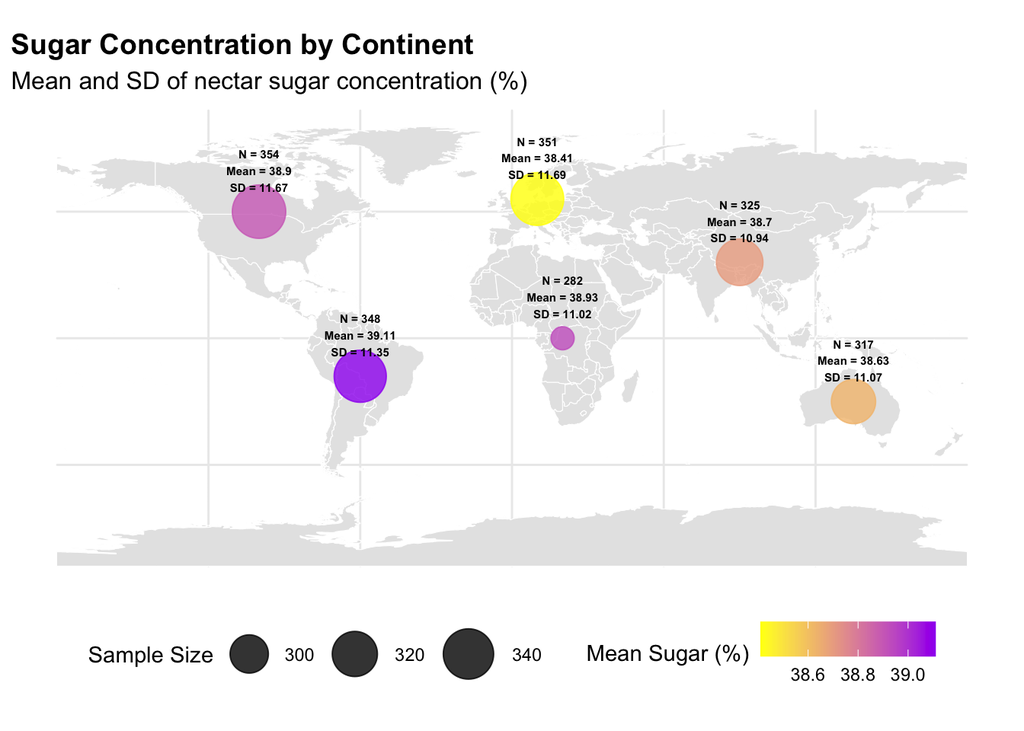

```r
# World map data
world <- ne_countries(scale = "medium", returnclass = "sf")



# Assume `continent_summary` has Mean, SD, and N for each region
# The coordinates for each continent should be pre-defined (example coordinates below)
continent_summary <- data.frame(
  Region = c("africa", "asia", "australia", "europe", "north_america", "south_america"),
  Mean = c(38.93, 38.70, 38.63, 38.41, 38.90, 39.11),
  SD = c(11.02, 10.94, 11.07, 11.69, 11.67, 11.35),
  N = c(282, 325, 317, 351, 354, 348),
  lon = c(20, 90, 135, 10, -100, -60),  # Longitude for continent centers
  lat = c(0, 30, -25, 55, 50, -15)     # Latitude for continent centers
)



# Load world map
world <- ne_countries(scale = "medium", returnclass = "sf")

# Data frame with coordinates, means, SD, and sample sizes
continent_summary <- data.frame(
  Region = c("africa", "asia", "australia", "europe", "north_america", "south_america"),
  Mean = c(38.93, 38.70, 38.63, 38.41, 38.90, 39.11),
  SD = c(11.02, 10.94, 11.07, 11.69, 11.67, 11.35),
  N = c(282, 325, 317, 351, 354, 348),
  lon = c(20, 90, 135, 10, -100, -60),  # Longitude for continent centers
  lat = c(0, 30, -25, 55, 50, -15)     # Latitude for continent centers
)

# Adjust position slightly upwards for text
continent_summary <- continent_summary %>%
  mutate(text_lat = lat + 8)  # Move text up by 8 latitude units

# Plot the map with aligned text above each continent
ggplot() +
  # Base world map
  geom_sf(data = world, fill = "grey90", color = "white") +

  # Points on the map for each continent
  geom_point(data = continent_summary, aes(x = lon, y = lat, size = N, color = Mean), alpha = 0.8) +
  scale_color_gradient(low = "yellow", high = "purple", name = "Mean Sugar (%)") +
  scale_size(range = c(5, 12), name = "Sample Size") +

  # Add text with N, Mean, and SD above the points
  geom_text(data = continent_summary, aes(x = lon, y = text_lat,
                                          label = paste0("N = ", N, "\nMean = ", Mean, "\nSD = ", SD)),
            size = 2, hjust = 0.5, vjust = 0, fontface = "bold") +

  # Titles and theme
  labs(
    title = "Sugar Concentration by Continent",
    subtitle = "Mean and SD of nectar sugar concentration (%)"
  ) +
  theme_minimal() +
  theme(
    legend.position = "bottom",
    plot.title = element_text(face = "bold", size = 14),
    plot.subtitle = element_text(size = 12),
    axis.text = element_blank(),
    axis.ticks = element_blank(),
    axis.title = element_blank()
  )
```

#### 6. Ecological Effects (Crops vs Weeds vs Wilds)

The comparison of nectar sugar concentrations among **crops**, **weeds**, and **wild plants** revealed distinct patterns:

Pairwise comparisons using **Dunn’s test** identified a **significant difference** between **wild plants and crops**, while no significant differences were observed between crops and weeds or weeds and wild plants (Figure 9).

These results suggest that wild plants may provide nectar with higher sugar concentrations compared to cultivated crops, possibly reflecting ecological adaptations.

**Figure 9: Ecological Effects ( Crops vs Weeds vs Wilds)**

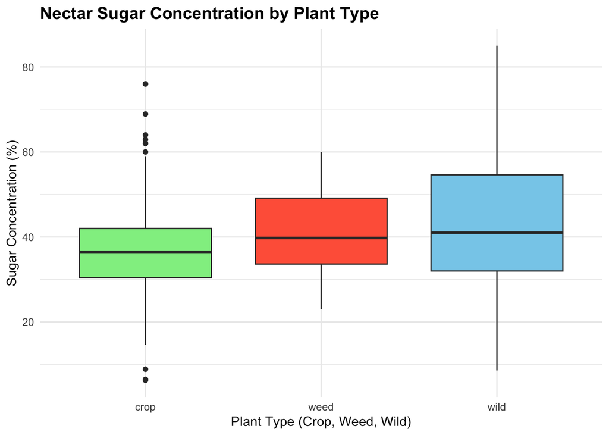

```r
# -----------------------------
# 1. Boxplot: Compare sugar concentration across types
# -----------------------------
# Filter out rows where 'type' is blank or NA
bee_data <- bee_data %>%
  filter(!is.na(type) & type != "")

ggplot(bee_data, aes(x = type, y = sugar_concentration, fill = type)) +
  geom_boxplot() +
  labs(
    title = "Nectar Sugar Concentration by Plant Type",
    x = "Plant Type (Crop, Weed, Wild)",
    y = "Sugar Concentration (%)"
  ) +
  scale_fill_manual(values = c("crop" = "lightgreen", "weed" = "tomato", "wild" = "skyblue")) +
  theme_minimal() +
  theme(
    plot.title = element_text(face = "bold", size = 14),
    legend.position = "none"
  )
```

```r
# -----------------------------
# 2. Kruskal-Wallis Test: Test for differences among the three groups
# -----------------------------
kruskal_result <- kruskal.test(sugar_concentration ~ type, data = bee_data)

# Print Kruskal-Wallis results
cat("\nKruskal-Wallis Test Results:\n")
```

```
Kruskal-Wallis Test Results:
```

```r
print(kruskal_result)
```

```
    Kruskal-Wallis rank sum test

data:  sugar_concentration by type
Kruskal-Wallis chi-squared = 15.78, df = 2, p-value = 0.0003745
```

```r
# -----------------------------
# 3. Dunn's Post-Hoc Test: Pairwise comparisons if Kruskal-Wallis is significant
# -----------------------------
if (kruskal_result$p.value < 0.05) {
  dunn_result <- dunnTest(sugar_concentration ~ type, data = bee_data, method = "bonferroni")

  # Format the results for better display
  dunn_result_df <- dunn_result$res
  dunn_result_df <- dunn_result_df %>%
    mutate(Significance = ifelse(P.adj < 0.05, "Significant", "Not Significant"))

  # Print pairwise results
  cat("\nDunn's Post-Hoc Test Results (Bonferroni Adjustment):\n")
  print(dunn_result_df)
} else {
  cat("\nNo significant differences found among the plant types.\n")
}
```

```
Dunn's Post-Hoc Test Results (Bonferroni Adjustment):
   Comparison           Z      P.unadj        P.adj    Significance
1 crop - weed -2.04787489 0.0405722598 0.1217167793 Not Significant
2 crop - wild -3.72802714 0.0001929846 0.0005789538     Significant
3 weed - wild  0.02924117 0.9766722477 1.0000000000 Not Significant
```

#### 7. Phylogenetic Analysis

The phylogenetic analysis revealed critical patterns regarding the evolutionary relationships of nectar sugar concentration across plant families. A heatmap aligned with the phylogenetic tree highlights specific trends and deviations in sugar production strategies.

#### **1. Families with Similar Nectar Sugar Concentrations**

- Three families, **Ranunculaceae, Costaceae, and Alstroemeriaceae**, exhibit notable similarities in nectar sugar concentrations despite their phylogenetic distance.
  - These families display moderate sugar concentrations (~40-50%), suggesting possible adaptations to generalist pollinators or similar environmental pressures.
  - The consistency across these families hints at **convergent evolution** for shared ecological strategies.

#### **2. Phylogenetic Signal and Proximity**

- Families that are phylogenetically **closer** often display clustering in nectar sugar concentrations.
  - For example, **Fabaceae** and **Rosaceae** show moderate sugar values, reflecting potential shared evolutionary traits.
  - However, families like **Ranunculaceae** and **Zygophyllaceae** deviate from this trend, demonstrating significantly higher sugar concentrations despite their phylogenetic distance.
  - This decoupling indicates the presence of **convergent evolution**, where unrelated families adapt to similar ecological pressures (e.g., pollinator specialization).

#### **3. Variability Within Families**

- Certain families exhibit **high variability** in sugar concentrations across genera, suggesting diverse pollination strategies within the same family:
  - **Solanaceae** and **Fabaceae** show a wide range of sugar values, indicating adaptation to multiple pollinator types or environmental niches.
  - This variability reflects **adaptive radiation**, where genera exploit different ecological conditions to maximize reproductive success.

### **Figure Legends**:

- **Figure 10**: Phylogenetic tree of families showing evolutionary relationships.
- **Figure 11**: Heatmap of nectar sugar concentrations aligned to the phylogenetic tree.

```r
# Ensure sugar concentration is numeric and filter out blank Family names
bee_data <- bee_data %>%
  filter(!is.na(Family) & Family != "", !is.na(sugar_concentration)) %>%
  mutate(sugar_concentration = as.numeric(sugar_concentration))

# Calculate mean sugar concentration for each unique family
mean_family_sugar <- bee_data %>%
  group_by(Family) %>%
  summarise(mean_sugar_concentration = mean(sugar_concentration, na.rm = TRUE)) %>%
  arrange(desc(mean_sugar_concentration))
# Step 1: List of family names
family_names <- as.character(mean_family_sugar$Family)  # Ensure 'Family' is character

# Step 2: Match family names to Open Tree of Life identifiers
matched_names <- tnrs_match_names(names = family_names)

# Step 3: Filter out unmatched names (NA IDs)
valid_matches <- matched_names %>%
  filter(!is.na(ott_id))  # Keep only valid IDs

# Step 4: Generate the phylogenetic tree using valid IDs
if (nrow(valid_matches) > 0) {
  tree <- tol_induced_subtree(ott_ids = valid_matches$ott_id)

  # Step 5: Check and assign default branch lengths if missing
  if (is.null(tree$edge.length)) {
    tree$edge.length <- rep(1, nrow(tree$edge))  # Assign equal branch lengths
  }

  # Shorten the branch lengths for better visualization
  phylotree <- ggtree(tree, size = 0.7) +  # Reduce branch thickness
    geom_tiplab(size = 3, align = TRUE, hjust = -0.1, linesize = 0.5) +  # Add tip labels
    labs(title = "Phylogenetic Tree of Families (Real Relationships)") +
    theme_tree2() +
    scale_x_continuous(expand = c(0, 4.5))  # Adjust X-axis space to fit labels
}
```

```
Progress [---------------------------------] 0/150 (  0%) ?s
Progress [==============================] 150/150 (100%)  0s
```

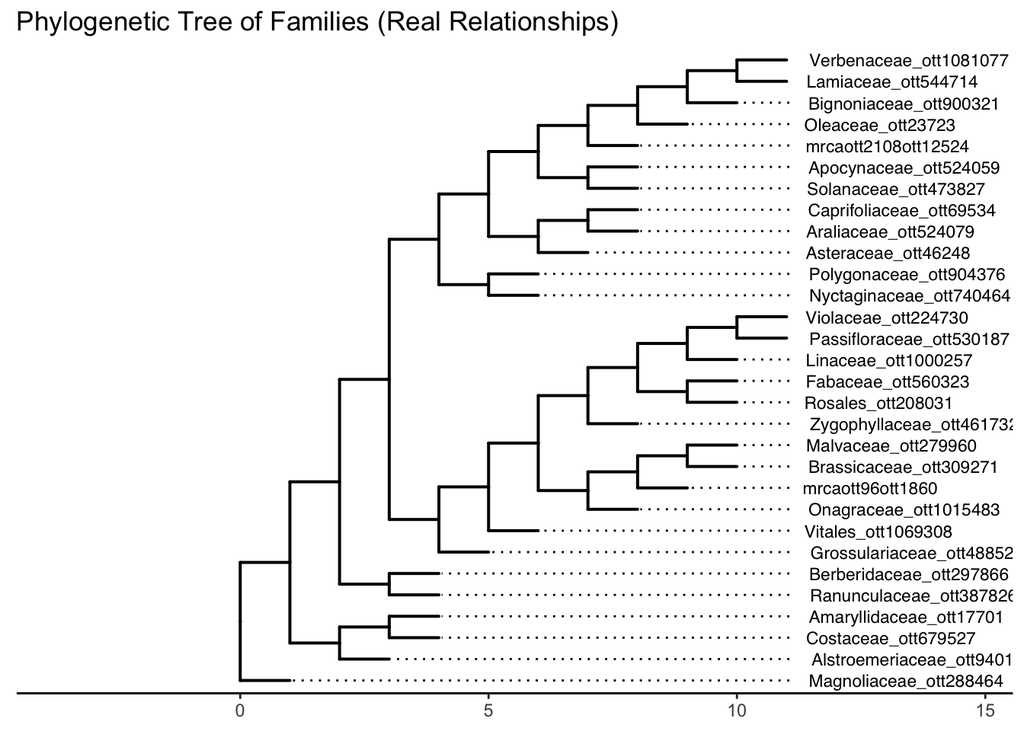

```r
phylotree
```

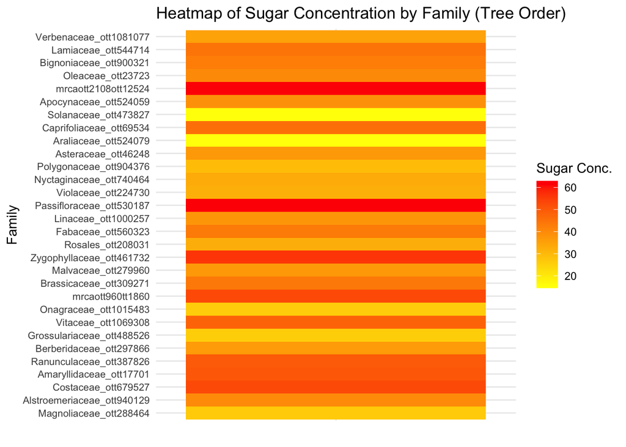

```r
# Step 1: Extract the ordered family names manually from the tree
ordered_families <- c(
  "Verbenaceae_ott1081077", "Lamiaceae_ott544714", "Bignoniaceae_ott900321",
  "Oleaceae_ott23723", "mrcaott2108ott12524", "Apocynaceae_ott524059",
  "Solanaceae_ott473827", "Caprifoliaceae_ott69534", "Araliaceae_ott524079",
  "Asteraceae_ott46248", "Polygonaceae_ott904376", "Nyctaginaceae_ott740464",
  "Violaceae_ott224730", "Passifloraceae_ott530187", "Linaceae_ott1000257",
  "Fabaceae_ott560323", "Rosales_ott208031", "Zygophyllaceae_ott461732",
  "Malvaceae_ott279960", "Brassicaceae_ott309271", "mrcaott960tt1860",
  "Onagraceae_ott1015483", "Vitaceae_ott1069308", "Grossulariaceae_ott488526",
  "Berberidaceae_ott297866", "Ranunculaceae_ott387826", "Amaryllidaceae_ott17701",
  "Costaceae_ott679527", "Alstroemeriaceae_ott940129", "Magnoliaceae_ott288464"
)

# Step 2: Match family names in ordered_families with closest names in mean_family_sugar
matched_names <- sapply(ordered_families, function(tree_name) {
  closest_match <- mean_family_sugar$Family[which.min(
    stringdist::stringdist(tree_name, mean_family_sugar$Family)
  )]
  return(closest_match)
})

# Step 3: Create a new table with matched names and sugar concentrations
heatmap_data <- data.frame(
  Tree_Family = ordered_families,       # Tree order
  Matched_Family = matched_names        # Closest names from mean_family_sugar
)

# Merge with sugar concentrations
heatmap_data <- heatmap_data %>%
  left_join(mean_family_sugar, by = c("Matched_Family" = "Family")) %>%
  mutate(Tree_Family = factor(Tree_Family, levels = ordered_families)) %>%
  select(Tree_Family, mean_sugar_concentration)

# Step 4: Plot the heatmap and reverse the Y-axis order
heatmapphylo <- ggplot(heatmap_data, aes(x = "", y = Tree_Family, fill = mean_sugar_concentration)) +
  geom_tile() +
  scale_fill_gradient(low = "yellow", high = "red", name = "Sugar Conc.") +
  scale_y_discrete(limits = rev(levels(heatmap_data$Tree_Family))) +  # Reverse the Y-axis order
  labs(title = "Heatmap of Sugar Concentration by Family (Tree Order)",
       x = "", y = "Family") +
  theme_minimal() +
  theme(axis.text.x = element_blank(),
        axis.ticks.x = element_blank(),
        axis.text.y = element_text(size = 8))  # Adjust text size for readability
heatmapphylo
```

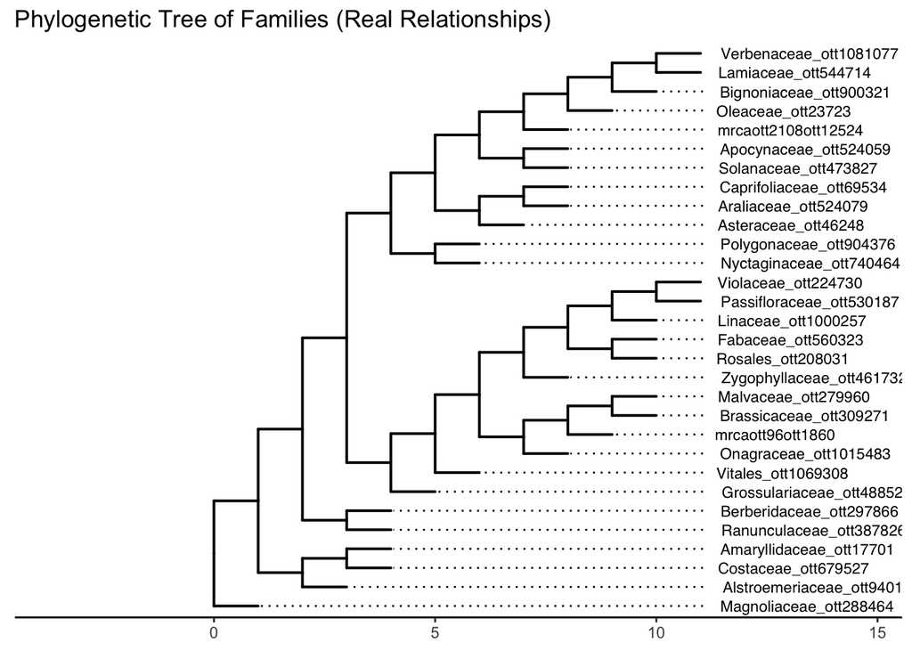

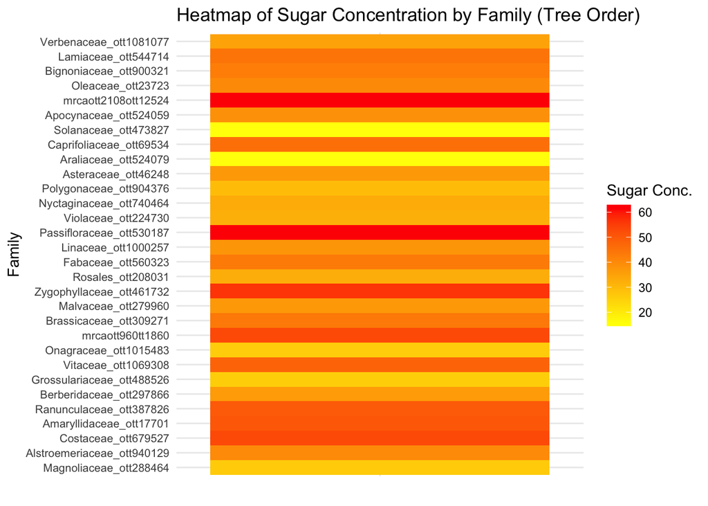

```r
phylotree
heatmapphylo
```

```

```

### Discussion

Our study investigated nectar sugar concentration variation across taxonomic levels, ecological categories (crops, weeds, and wild plants), and geographical regions, providing insights into how plant taxonomy and ecological context shape nectar traits. Overall, the results support the primary hypothesis that plant taxonomy (family and genus) is a key determinant of nectar sugar concentration.

### Taxonomic Patterns and Random Effects

The linear mixed-effects model revealed that **genus-level variation within families** was substantial. Some genera demonstrated markedly positive or negative random effects, suggesting that while family-level phylogenetic constraints set a broad “template” for nectar sugar concentration, individual genera within a family can deviate substantially. This underscores the importance of both higher-level evolutionary histories (family-level constraints) and finer-scale adaptations (genus-level diversification), possibly reflecting localized ecological interactions with different pollinator guilds (Rodríguez-Gironés & Santamaría, 2004; Nicolson & Thornburg, 2007).

### Ecological Effects: Crops vs. Weeds vs. Wild Plants

Our comparisons among crops, weeds, and wild plant species revealed that **wild plants exhibited the highest median sugar concentration**, followed by weeds and then crops. This pattern could stem from different selective pressures in agricultural vs. natural habitats. Domesticated crops may not be under as strong a selective pressure to produce high-sugar nectar if breeding programs prioritize traits such as yield and pest resistance rather than pollinator attraction. Conversely, wild species rely heavily on pollinators for reproductive success, potentially favoring higher sugar nectar as an enticement (Pacini & Nepi, 2007). These findings mirror similar studies noting that human-mediated selection can reduce or alter floral rewards relative to wild relatives (Stiles & Freeman, 1993).

### Geographical and Environmental Factors

Despite initial expectations that climatic factors—such as temperature, rainfall, or latitude—might drive geographic variation in nectar sugar concentration (Stiles & Freeman, 1993; Petanidou, 2005), our analyses found **no statistically significant differences** among continents. It is important to note, however, that the geographical effects in our dataset are largely **an artifact**: because the same plant species can be recorded as occurring in multiple continents, the data are not strictly suitable for making definitive cross-continental comparisons. As a result, our finding of “no significant differences” likely reflects this limitation rather than a robust conclusion about the environmental influences on nectar traits.

### Implications and Future Directions

Taken together, our findings highlight that **taxonomy—particularly at the family and genus levels—remains a primary driver** of nectar sugar concentration, whereas broad-scale geographic differences appear less pronounced in this dataset. The distinctively higher sugar concentrations in wild plants emphasize potential ecological implications for pollinator conservation, as cultivated landscapes might offer comparatively lower nectar rewards (Chalcoff et al., 2006). Future work would benefit from integrating additional environmental measures (e.g., local climate data, land use intensity, pollinator community composition) and expanding taxonomic coverage to underrepresented families and regions.

Additionally, understanding the **mechanistic basis** of how genetic, physiological, and ecological factors converge to produce such wide taxonomic variation could clarify the evolution of plant-pollinator interactions. For instance, manipulative experiments that measure pollinator visitation alongside nectar sugar concentration could shed light on how pollinator preferences shape sugar traits within and across families (Rodríguez-Gironés & Santamaría, 2004). Lastly, coupling trait-based approaches (e.g., sugar composition, nectar volume) with phylogenomic analyses could illuminate the genetic underpinnings behind convergent versus divergent nectar strategies in distantly or closely related lineages.

### Conclusion

Although we initially examined potential geographical differences in sugar concentration, our data reveal that these patterns are largely **an artifact**: many plant species were recorded across multiple continents, rendering any true cross-continental comparisons invalid. Thus, any apparent regional variation is driven more by **which families are present** than by environmental factors per se. In light of this, future research should employ datasets with stricter geographic controls, ensuring distinct species sets for each region to assess genuine environmental impacts on nectar traits.

Taken as a whole, our study points to strong taxonomic control over nectar sugar concentration, with only limited evidence of geographical influence under these data constraints. Going forward, refining phylogenetic analyses and strengthening geographic delineations will clarify how nectar traits adapt to local climates and pollinator communities, ultimately helping to guide conservation and agricultural strategies that support pollinator health

### References

- Chalcoff, V. R., A. G. Ezcurra, & A. A. Cocucci. (2006). Phylogenetic analysis of floral traits in species of the tribe Mutisieae (Asteraceae) and its ecological implications. *Annals of Botany, 98*(3), 583–594.
- Nicolson, S. W., & Thornburg, R. W. (2007). Nectar chemistry. In S. W. Nicolson, M. Nepi, & E. Pacini (Eds.), *Nectaries and Nectar* (pp. 215–264). Springer.
- Ornelas, J. F., Ordano, M., De-Nova, J. A., Quintero, M. E., & Garland, T. (2019). Phylogenetic analysis of interspecific variation in nectar sugar composition in hummingbird-visited plants. *PeerJ, 7*, e6329.
- Pacini, E., & Nepi, M. (2007). Nectar production and presentation. In S. W. Nicolson, M. Nepi, & E. Pacini (Eds.), *Nectaries and Nectar* (pp. 167–214). Springer.
- Perret, M., Chautems, A., Spichiger, R., Kite, G., & Favarge, P. (2001). Systematics and evolution of Tribe Sinningieae (Gesneriaceae): Evidence from phylogenetic analysis of six plastid DNA regions and nuclear ribosomal DNA ITS. *American Journal of Botany, 88*(6), 1003–1016.
- Rodríguez-Gironés, M. A., & Santamaría, L. (2004). Why are so many bird flowers red? Pollen loading as a possible selective agent. *Evolutionary Ecology Research, 6*, 777–785.
- Stiles, F. G., & Freeman, C. E. (1993). Patterns in flower phenology and hummingbird visitation among upper montane forests in Costa Rica. *Ecology, 74*(3), 556–567.
- Chalcoff, V. R., Aizen, M. A., & Galetto, L. (2006). Nectar concentration and composition of 26 species from the temperate forest of South America. *Annals of Botany, 97*(3), 413–421.
- Perret, M., Chautems, A., Spichiger, R., Peixoto, M., & Varadarajan, G. (2001). Nectar sugar composition in relation to pollination syndromes in Sinningieae (Gesneriaceae). *Annals of Botany, 87*(2), 267–273.
- Petanidou, T. (2005). Sugars in Mediterranean floral nectars: An ecological and evolutionary approach. *Journal of Chemical Ecology, 31*(5), 1065–1088.
- Rodríguez-Gironés, M. A., & Santamaría, L. (2004). Why are so many bird flowers red? *PLoS Biology, 2*(10), e350.
- Stiles, F. G., & Freeman, C. E. (1993). Patterns in floral nectar characteristics of some bird-visited plant species from Costa Rica. *Biotropica, 25*(2), 191–205.